# Project 6 - Recommendation Systems

#### Domain - E-commerce

Context - Everyday a million products are being recommended to users based on popularity and other metrics on e-commerce websites. The most popular e-commerce website boosts average order value by 50%, increases revenues by 300%, and improves conversion. In addition to being a powerful tool for increasing revenues, product recommendations are so essential that customers now expect to see similar features on all other eCommerce sites.

```python
# importing libraries

import numpy as np
import pandas as pd
import matplotlib.pyplot as plt
import seaborn as sns


import warnings
warnings.filterwarnings('ignore')
```

### 1. Read and explore the given dataset

```python
# reading the data into a dataframe

ratings_df = pd.read_csv("ratings_Electronics.csv")
```

```python
# checking the top five records

ratings_df.head()
```

|  | AKM1MP6P0OYPR | 0132793040 | 5.0 | 1365811200 |
| --- | --- | --- | --- | --- |
| 0 | A2CX7LUOHB2NDG | 0321732944 | 5.0 | 1341100800 |
| 1 | A2NWSAGRHCP8N5 | 0439886341 | 1.0 | 1367193600 |
| 2 | A2WNBOD3WNDNKT | 0439886341 | 3.0 | 1374451200 |
| 3 | A1GI0U4ZRJA8WN | 0439886341 | 1.0 | 1334707200 |
| 4 | A1QGNMC6O1VW39 | 0511189877 | 5.0 | 1397433600 |

```python
# defining column names as they are missing

ratings_df.columns=['UserId', 'ProductId', 'Rating', 'TimeStamp']
```

```python
# checking the dataframe with column names

ratings_df.head()
```

|  | UserId | ProductId | Rating | TimeStamp |
| --- | --- | --- | --- | --- |
| 0 | A2CX7LUOHB2NDG | 0321732944 | 5.0 | 1341100800 |
| 1 | A2NWSAGRHCP8N5 | 0439886341 | 1.0 | 1367193600 |
| 2 | A2WNBOD3WNDNKT | 0439886341 | 3.0 | 1374451200 |
| 3 | A1GI0U4ZRJA8WN | 0439886341 | 1.0 | 1334707200 |
| 4 | A1QGNMC6O1VW39 | 0511189877 | 5.0 | 1397433600 |

```python
# Check for missing values present
print('Number of missing values across columns-\n', ratings_df.isnull().sum())
```

```
Number of missing values across columns-
 UserId       0
ProductId    0
Rating       0
TimeStamp    0
dtype: int64
```

```python
# dropping timestamp as we will not using this for analysis

ratings_df = ratings_df.drop(columns=['TimeStamp'])
```

```python
# checking the dataframe after dropping the column

ratings_df.head()
```

|  | UserId | ProductId | Rating |
| --- | --- | --- | --- |
| 0 | A2CX7LUOHB2NDG | 0321732944 | 5.0 |
| 1 | A2NWSAGRHCP8N5 | 0439886341 | 1.0 |
| 2 | A2WNBOD3WNDNKT | 0439886341 | 3.0 |
| 3 | A1GI0U4ZRJA8WN | 0439886341 | 1.0 |
| 4 | A1QGNMC6O1VW39 | 0511189877 | 5.0 |

```python
# checking the data shape as we have arrived at the dataframe to be used further

ratings_df.shape
```

```
(7824481, 3)
```

```python
ratings_df.dtypes
```

```
UserId        object
ProductId     object
Rating       float64
dtype: object
```

```python
# Summary statistics of 'rating' variable
ratings_df['Rating'].describe().transpose()
```

```
count    7.824481e+06
mean     4.012337e+00
std      1.380910e+00
min      1.000000e+00
25%      3.000000e+00
50%      5.000000e+00
75%      5.000000e+00
max      5.000000e+00
Name: Rating, dtype: float64
```

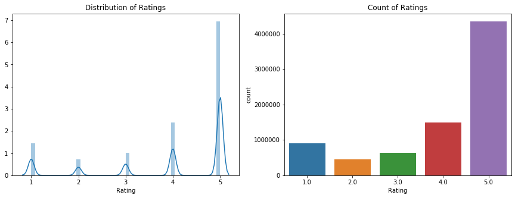

```python
# Understading the distribution of the ratings across products

fig = plt.figure(figsize = (15, 5))
ax = fig.add_subplot(121)

g = sns.distplot(ratings_df['Rating'], ax = ax).set_title('Distribution of Ratings')
ax = fig.add_subplot(122)

g = sns.countplot(ratings_df['Rating']).set_title('Count of Ratings')
```

```python
# Number of unique user id and product id in the data
print('Number of unique USERS in Raw data = ', ratings_df['UserId'].nunique())
print('Number of unique ITEMS in Raw data = ', ratings_df['ProductId'].nunique())
```

```
Number of unique USERS in Raw data =  4201696
Number of unique ITEMS in Raw data =  476001
```

```python
# Top 10 users based on rating
most_rated = ratings_df.groupby('UserId').size().sort_values(ascending=False)[:10]
most_rated
```

```
UserId
A5JLAU2ARJ0BO     520
ADLVFFE4VBT8      501
A3OXHLG6DIBRW8    498
A6FIAB28IS79      431
A680RUE1FDO8B     406
A1ODOGXEYECQQ8    380
A36K2N527TXXJN    314
A2AY4YUOX2N1BQ    311
AWPODHOB4GFWL     308
A25C2M3QF9G7OQ    296
dtype: int64
```

#### Observations

1. There are a total of 7824481 records in the dataframe with three key columns of User Id, Product Id and the corresponding rating by a user
2. In the given dataset many users seem to be happy with the products and above 4 million people have rated 5
3. Around 1 million users have rated the product not good
4. Max rating is of 5 and minimum rating is 1
5. Both User id and Product Id are of type object while Rating is numerical
6. There are 4201696 unique users and 476001 no. of unique items/products
7. There are no null values

### 2. Take a subset of the dataset to make it less sparse/ denser

```python
# creating a subset where the users have rated more than 50 products

ratings_new = ratings_df[ratings_df.groupby('UserId')['UserId'].transform('size')>50]
```

```python
print('Number of users who have rated more than 50 items =', len(ratings_new))
print('Number of unique USERS in final data = ', ratings_new['UserId'].nunique())
print('Number of unique ITEMS in final data = ', ratings_new['ProductId'].nunique())
```

```
Number of users who have rated more than 50 items = 122171
Number of unique USERS in final data =  1466
Number of unique ITEMS in final data =  47155
```

```python
ratings_new.head()
```

|  | UserId | ProductId | Rating |
| --- | --- | --- | --- |
| 117 | AT09WGFUM934H | 0594481813 | 3.0 |
| 176 | A32HSNCNPRUMTR | 0970407998 | 1.0 |
| 177 | A17HMM1M7T9PJ1 | 0970407998 | 4.0 |
| 491 | A3CLWR1UUZT6TG | 0972683275 | 5.0 |
| 630 | A3TAS1AG6FMBQW | 0972683275 | 5.0 |

```python
# checking the shape of the new dataframe

ratings_new.shape
```

```
(122171, 3)
```

```python
# checking for any null values in the new dataframe

ratings_new.isnull().sum()
```

```
UserId       0
ProductId    0
Rating       0
dtype: int64
```

#### Calculate the density of the new matrix

```python
final_ratings_matrix = ratings_new.pivot(index = 'UserId', columns ='ProductId', values = 'Rating').fillna(0)
print('Shape of final_ratings_matrix: ', final_ratings_matrix.shape)

given_num_of_ratings = np.count_nonzero(final_ratings_matrix)
print('given_num_of_ratings = ', given_num_of_ratings)
possible_num_of_ratings = final_ratings_matrix.shape[0] * final_ratings_matrix.shape[1]
print('possible_num_of_ratings = ', possible_num_of_ratings)
density = (given_num_of_ratings/possible_num_of_ratings)
density *= 100
print ('density: {:4.2f}%'.format(density))
```

```
Shape of final_ratings_matrix:  (1466, 47155)
given_num_of_ratings =  122171
possible_num_of_ratings =  69129230
density: 0.18%
```

```python
final_ratings_matrix.head()
```

| ProductId UserId | 0594481813 | 0970407998 | 0972683275 | 1400501466 | 1400501520 | 1400501776 | 1400532620 | 1400532655 | 140053271X | 1400599997 | ... | B00L5YZCCG | B00L8I6SFY | B00L8QCVL6 | B00LA6T0LS | B00LBZ1Z7K | B00LED02VY | B00LGN7Y3G | B00LGQ6HL8 | B00LI4ZZO8 | B00LKG1MC8 |
| --- | --- | --- | --- | --- | --- | --- | --- | --- | --- | --- | --- | --- | --- | --- | --- | --- | --- | --- | --- | --- | --- |
| A100UD67AHFODS | 0.0 | 0.0 | 0.0 | 0.0 | 0.0 | 0.0 | 0.0 | 0.0 | 0.0 | 0.0 | ... | 0.0 | 0.0 | 0.0 | 0.0 | 0.0 | 0.0 | 0.0 | 0.0 | 0.0 | 0.0 |
| A100WO06OQR8BQ | 0.0 | 0.0 | 0.0 | 0.0 | 0.0 | 0.0 | 0.0 | 0.0 | 0.0 | 0.0 | ... | 0.0 | 0.0 | 0.0 | 0.0 | 0.0 | 0.0 | 0.0 | 0.0 | 0.0 | 0.0 |
| A105S56ODHGJEK | 0.0 | 0.0 | 0.0 | 0.0 | 0.0 | 0.0 | 0.0 | 0.0 | 0.0 | 0.0 | ... | 0.0 | 0.0 | 0.0 | 0.0 | 0.0 | 0.0 | 0.0 | 0.0 | 0.0 | 0.0 |
| A105TOJ6LTVMBG | 0.0 | 0.0 | 0.0 | 0.0 | 0.0 | 0.0 | 0.0 | 0.0 | 0.0 | 0.0 | ... | 0.0 | 0.0 | 0.0 | 0.0 | 0.0 | 0.0 | 0.0 | 0.0 | 0.0 | 0.0 |
| A10AFVU66A79Y1 | 0.0 | 0.0 | 0.0 | 0.0 | 0.0 | 0.0 | 0.0 | 0.0 | 0.0 | 0.0 | ... | 0.0 | 0.0 | 0.0 | 0.0 | 0.0 | 0.0 | 0.0 | 0.0 | 0.0 | 0.0 |

5 rows × 47155 columns

```python
# Matrix with one row per 'Product' and one column per 'user' for Item-based CF
final_ratings_matrix_T = final_ratings_matrix.transpose()
final_ratings_matrix_T.head()
```

| UserId ProductId | A100UD67AHFODS | A100WO06OQR8BQ | A105S56ODHGJEK | A105TOJ6LTVMBG | A10AFVU66A79Y1 | A10H24TDLK2VDP | A10NMELR4KX0J6 | A10O7THJ2O20AG | A10PEXB6XAQ5XF | A10X9ME6R66JDX | ... | AYOTEJ617O60K | AYP0YPLSP9ISM | AZ515FFZ7I2P7 | AZ8XSDMIX04VJ | AZAC8O310IK4E | AZBXKUH4AIW3X | AZCE11PSTCH1L | AZMY6E8B52L2T | AZNUHQSHZHSUE | AZOK5STV85FBJ |
| --- | --- | --- | --- | --- | --- | --- | --- | --- | --- | --- | --- | --- | --- | --- | --- | --- | --- | --- | --- | --- | --- |
| 0594481813 | 0.0 | 0.0 | 0.0 | 0.0 | 0.0 | 0.0 | 0.0 | 0.0 | 0.0 | 0.0 | ... | 0.0 | 0.0 | 0.0 | 0.0 | 0.0 | 0.0 | 0.0 | 0.0 | 0.0 | 0.0 |
| 0970407998 | 0.0 | 0.0 | 0.0 | 0.0 | 0.0 | 0.0 | 0.0 | 0.0 | 0.0 | 0.0 | ... | 0.0 | 0.0 | 0.0 | 0.0 | 0.0 | 0.0 | 0.0 | 0.0 | 0.0 | 0.0 |
| 0972683275 | 0.0 | 0.0 | 0.0 | 0.0 | 0.0 | 0.0 | 0.0 | 0.0 | 0.0 | 0.0 | ... | 0.0 | 0.0 | 0.0 | 0.0 | 0.0 | 0.0 | 0.0 | 0.0 | 0.0 | 0.0 |
| 1400501466 | 0.0 | 0.0 | 0.0 | 0.0 | 0.0 | 0.0 | 0.0 | 0.0 | 0.0 | 0.0 | ... | 0.0 | 0.0 | 0.0 | 0.0 | 0.0 | 0.0 | 0.0 | 0.0 | 0.0 | 0.0 |
| 1400501520 | 0.0 | 0.0 | 0.0 | 0.0 | 0.0 | 0.0 | 0.0 | 0.0 | 0.0 | 0.0 | ... | 0.0 | 0.0 | 0.0 | 0.0 | 0.0 | 0.0 | 0.0 | 0.0 | 0.0 | 0.0 |

5 rows × 1466 columns

#### Observations

Lets explore further!

### 3. Approach one - No Suprise :(

#### 3.a. Split the data randomly into a train and test dataset

```python
#Split the data randomnly into test and train datasets in the ratio 30:70

from sklearn.model_selection import train_test_split

train_data, test_data = train_test_split(ratings_new, test_size = 0.3, random_state=25)
train_data.head()
```

|  | UserId | ProductId | Rating |
| --- | --- | --- | --- |
| 399215 | A1E1LEVQ9VQNK | B0001LFRIS | 5.0 |
| 1150597 | A30R8VFR16RE32 | B000M3ILF6 | 5.0 |
| 6748193 | A16CVJUQOB6GIB | B009VTDT22 | 5.0 |
| 3938364 | A24QFMD1RXLJMB | B0047ZGIUK | 5.0 |
| 5458190 | AENULRBQ2IE5I | B006PWGEVQ | 5.0 |

```python
train_data.shape
```

```
(85519, 3)
```

```python
test_data.shape
```

```
(36652, 3)
```

#### Observations

The new dataframe is split into 30:70 for test:train. There are around 85k records in the train dataset and 36k records in the test data set.

#### 3.b. Build a popularity based model

```python
#Count of user_id for each unique product as recommendation score
train_data_grouped = train_data.groupby('ProductId').agg({'UserId': 'count'}).reset_index()
train_data_grouped.rename(columns = {'UserId': 'score'},inplace=True)
train_data_grouped.head()
```

|  | ProductId | score |
| --- | --- | --- |
| 0 | 0594481813 | 1 |
| 1 | 0970407998 | 1 |
| 2 | 0972683275 | 2 |
| 3 | 1400501466 | 3 |
| 4 | 1400501520 | 1 |

```python
#Sort the products on recommendation score which is nothing but the frequency of the users rating a product

train_data_sort = train_data_grouped.sort_values(['score', 'ProductId'], ascending = [0,1])

#Generate a recommendation rank based upon score
train_data_sort['Rank'] = train_data_sort['score'].rank(ascending=0, method='first')

#Get the top 5 recommendations
popularity_recommendations = train_data_sort.head(5)
popularity_recommendations
```

|  | ProductId | score | Rank |
| --- | --- | --- | --- |
| 30198 | B0088CJT4U | 144 | 1.0 |
| 19178 | B003ES5ZUU | 121 | 2.0 |
| 8493 | B000N99BBC | 117 | 3.0 |
| 29903 | B00829TIEK | 115 | 4.0 |
| 30443 | B008DWCRQW | 111 | 5.0 |

These are the 5 products recommended for any user.

#### Observations

Since this is a popularity-based recommender model, recommendations remain the same for all users We predict the products based on the popularity. It is not personalized to particular user

#### 3.c. Build a Collaborative Filtering model

```python
Ratings_CF = pd.concat([train_data, test_data]).reset_index()
Ratings_CF.head()
```

|  | index | UserId | ProductId | Rating |
| --- | --- | --- | --- | --- |
| 0 | 399215 | A1E1LEVQ9VQNK | B0001LFRIS | 5.0 |
| 1 | 1150597 | A30R8VFR16RE32 | B000M3ILF6 | 5.0 |
| 2 | 6748193 | A16CVJUQOB6GIB | B009VTDT22 | 5.0 |
| 3 | 3938364 | A24QFMD1RXLJMB | B0047ZGIUK | 5.0 |
| 4 | 5458190 | AENULRBQ2IE5I | B006PWGEVQ | 5.0 |

##### User-based Collaborative Filtering

```python
# Matrix with row per 'user' and column per 'item'

pivot_df = Ratings_CF.pivot(index = 'UserId', columns ='ProductId', values = 'Rating').fillna(0)
pivot_df.shape
pivot_df.head()
```

| ProductId UserId | 0594481813 | 0970407998 | 0972683275 | 1400501466 | 1400501520 | 1400501776 | 1400532620 | 1400532655 | 140053271X | 1400599997 | ... | B00L5YZCCG | B00L8I6SFY | B00L8QCVL6 | B00LA6T0LS | B00LBZ1Z7K | B00LED02VY | B00LGN7Y3G | B00LGQ6HL8 | B00LI4ZZO8 | B00LKG1MC8 |
| --- | --- | --- | --- | --- | --- | --- | --- | --- | --- | --- | --- | --- | --- | --- | --- | --- | --- | --- | --- | --- | --- |
| A100UD67AHFODS | 0.0 | 0.0 | 0.0 | 0.0 | 0.0 | 0.0 | 0.0 | 0.0 | 0.0 | 0.0 | ... | 0.0 | 0.0 | 0.0 | 0.0 | 0.0 | 0.0 | 0.0 | 0.0 | 0.0 | 0.0 |
| A100WO06OQR8BQ | 0.0 | 0.0 | 0.0 | 0.0 | 0.0 | 0.0 | 0.0 | 0.0 | 0.0 | 0.0 | ... | 0.0 | 0.0 | 0.0 | 0.0 | 0.0 | 0.0 | 0.0 | 0.0 | 0.0 | 0.0 |
| A105S56ODHGJEK | 0.0 | 0.0 | 0.0 | 0.0 | 0.0 | 0.0 | 0.0 | 0.0 | 0.0 | 0.0 | ... | 0.0 | 0.0 | 0.0 | 0.0 | 0.0 | 0.0 | 0.0 | 0.0 | 0.0 | 0.0 |
| A105TOJ6LTVMBG | 0.0 | 0.0 | 0.0 | 0.0 | 0.0 | 0.0 | 0.0 | 0.0 | 0.0 | 0.0 | ... | 0.0 | 0.0 | 0.0 | 0.0 | 0.0 | 0.0 | 0.0 | 0.0 | 0.0 | 0.0 |
| A10AFVU66A79Y1 | 0.0 | 0.0 | 0.0 | 0.0 | 0.0 | 0.0 | 0.0 | 0.0 | 0.0 | 0.0 | ... | 0.0 | 0.0 | 0.0 | 0.0 | 0.0 | 0.0 | 0.0 | 0.0 | 0.0 | 0.0 |

5 rows × 47155 columns

```python
pivot_df['user_index'] = np.arange(0, pivot_df.shape[0], 1)
pivot_df.head()
```

| ProductId UserId | 0594481813 | 0970407998 | 0972683275 | 1400501466 | 1400501520 | 1400501776 | 1400532620 | 1400532655 | 140053271X | 1400599997 | ... | B00L8I6SFY | B00L8QCVL6 | B00LA6T0LS | B00LBZ1Z7K | B00LED02VY | B00LGN7Y3G | B00LGQ6HL8 | B00LI4ZZO8 | B00LKG1MC8 | user_index |
| --- | --- | --- | --- | --- | --- | --- | --- | --- | --- | --- | --- | --- | --- | --- | --- | --- | --- | --- | --- | --- | --- |
| A100UD67AHFODS | 0.0 | 0.0 | 0.0 | 0.0 | 0.0 | 0.0 | 0.0 | 0.0 | 0.0 | 0.0 | ... | 0.0 | 0.0 | 0.0 | 0.0 | 0.0 | 0.0 | 0.0 | 0.0 | 0.0 | 0 |
| A100WO06OQR8BQ | 0.0 | 0.0 | 0.0 | 0.0 | 0.0 | 0.0 | 0.0 | 0.0 | 0.0 | 0.0 | ... | 0.0 | 0.0 | 0.0 | 0.0 | 0.0 | 0.0 | 0.0 | 0.0 | 0.0 | 1 |
| A105S56ODHGJEK | 0.0 | 0.0 | 0.0 | 0.0 | 0.0 | 0.0 | 0.0 | 0.0 | 0.0 | 0.0 | ... | 0.0 | 0.0 | 0.0 | 0.0 | 0.0 | 0.0 | 0.0 | 0.0 | 0.0 | 2 |
| A105TOJ6LTVMBG | 0.0 | 0.0 | 0.0 | 0.0 | 0.0 | 0.0 | 0.0 | 0.0 | 0.0 | 0.0 | ... | 0.0 | 0.0 | 0.0 | 0.0 | 0.0 | 0.0 | 0.0 | 0.0 | 0.0 | 3 |
| A10AFVU66A79Y1 | 0.0 | 0.0 | 0.0 | 0.0 | 0.0 | 0.0 | 0.0 | 0.0 | 0.0 | 0.0 | ... | 0.0 | 0.0 | 0.0 | 0.0 | 0.0 | 0.0 | 0.0 | 0.0 | 0.0 | 4 |

5 rows × 47156 columns

```python
pivot_df.set_index(['user_index'], inplace=True)

# Actual ratings given by users
pivot_df.head()
```

| ProductId user_index | 0594481813 | 0970407998 | 0972683275 | 1400501466 | 1400501520 | 1400501776 | 1400532620 | 1400532655 | 140053271X | 1400599997 | ... | B00L5YZCCG | B00L8I6SFY | B00L8QCVL6 | B00LA6T0LS | B00LBZ1Z7K | B00LED02VY | B00LGN7Y3G | B00LGQ6HL8 | B00LI4ZZO8 | B00LKG1MC8 |
| --- | --- | --- | --- | --- | --- | --- | --- | --- | --- | --- | --- | --- | --- | --- | --- | --- | --- | --- | --- | --- | --- |
| 0 | 0.0 | 0.0 | 0.0 | 0.0 | 0.0 | 0.0 | 0.0 | 0.0 | 0.0 | 0.0 | ... | 0.0 | 0.0 | 0.0 | 0.0 | 0.0 | 0.0 | 0.0 | 0.0 | 0.0 | 0.0 |
| 1 | 0.0 | 0.0 | 0.0 | 0.0 | 0.0 | 0.0 | 0.0 | 0.0 | 0.0 | 0.0 | ... | 0.0 | 0.0 | 0.0 | 0.0 | 0.0 | 0.0 | 0.0 | 0.0 | 0.0 | 0.0 |
| 2 | 0.0 | 0.0 | 0.0 | 0.0 | 0.0 | 0.0 | 0.0 | 0.0 | 0.0 | 0.0 | ... | 0.0 | 0.0 | 0.0 | 0.0 | 0.0 | 0.0 | 0.0 | 0.0 | 0.0 | 0.0 |
| 3 | 0.0 | 0.0 | 0.0 | 0.0 | 0.0 | 0.0 | 0.0 | 0.0 | 0.0 | 0.0 | ... | 0.0 | 0.0 | 0.0 | 0.0 | 0.0 | 0.0 | 0.0 | 0.0 | 0.0 | 0.0 |
| 4 | 0.0 | 0.0 | 0.0 | 0.0 | 0.0 | 0.0 | 0.0 | 0.0 | 0.0 | 0.0 | ... | 0.0 | 0.0 | 0.0 | 0.0 | 0.0 | 0.0 | 0.0 | 0.0 | 0.0 | 0.0 |

5 rows × 47155 columns

```python
pivot_df.shape
```

```
(1466, 47155)
```

#### Using SVD

```python
from scipy.sparse.linalg import svds

# Singular Value Decomposition
U, sigma, Vt = svds(pivot_df, k = 10)

# Construct diagonal array in SVD
sigma = np.diag(sigma)
```

```python
user_predicted_ratings = np.dot(np.dot(U, sigma), Vt)

# Predicted ratings
preds_df = pd.DataFrame(user_predicted_ratings, columns = pivot_df.columns)
preds_df.head()
```

| ProductId | 0594481813 | 0970407998 | 0972683275 | 1400501466 | 1400501520 | 1400501776 | 1400532620 | 1400532655 | 140053271X | 1400599997 | ... | B00L5YZCCG | B00L8I6SFY | B00L8QCVL6 | B00LA6T0LS | B00LBZ1Z7K | B00LED02VY | B00LGN7Y3G | B00LGQ6HL8 | B00LI4ZZO8 | B00LKG1MC8 |
| --- | --- | --- | --- | --- | --- | --- | --- | --- | --- | --- | --- | --- | --- | --- | --- | --- | --- | --- | --- | --- | --- |
| 0 | 0.003574 | 0.004106 | 0.004114 | 0.001519 | 0.003071 | 0.005844 | 0.000504 | 0.010546 | 0.002704 | 0.000367 | ... | 0.000605 | 0.044718 | 0.002920 | 0.060948 | -0.002402 | 0.006796 | 0.001514 | 0.131030 | 0.059635 | 0.015090 |
| 1 | 0.002569 | 0.005363 | 0.013273 | 0.006607 | 0.001513 | 0.013490 | 0.000304 | -0.004528 | 0.001254 | 0.011161 | ... | 0.000228 | 0.029384 | 0.000089 | 0.000636 | -0.003266 | -0.000550 | 0.004386 | -0.039361 | -0.006408 | 0.003812 |
| 2 | -0.002541 | 0.002095 | 0.017831 | 0.006890 | -0.002171 | 0.005816 | 0.003470 | -0.004045 | -0.001645 | 0.010979 | ... | -0.000323 | 0.009498 | -0.002494 | -0.016874 | 0.019722 | -0.002480 | -0.000172 | -0.003130 | -0.011089 | -0.004675 |
| 3 | 0.003963 | 0.001919 | 0.007592 | 0.002871 | 0.002890 | 0.003592 | 0.000112 | 0.005946 | 0.002477 | 0.000063 | ... | 0.000616 | -0.003098 | 0.003469 | -0.003241 | -0.000767 | 0.000159 | 0.002695 | -0.015041 | -0.007067 | 0.003539 |
| 4 | 0.000112 | 0.002091 | 0.008902 | 0.004068 | 0.000342 | 0.006062 | 0.001018 | -0.000888 | 0.000375 | 0.006435 | ... | 0.000007 | -0.000698 | -0.000316 | -0.024802 | 0.004501 | -0.002146 | 0.001284 | -0.048613 | -0.016151 | -0.003332 |

5 rows × 47155 columns

```python
# Recommend the items with the highest predicted ratings

def recommend_items(user_id, pivot_df, preds_df, num_recommendations):

    #sorted_user_ratings
    sorted_user_ratings = pivot_df.iloc[user_id].sort_values(ascending=False)

    #sorted_user_predictions
    sorted_user_predictions = preds_df.iloc[user_id].sort_values(ascending=False)

    temp = pd.concat([sorted_user_ratings, sorted_user_predictions], axis=1)

    temp.index.name = 'Recommended Items'
    temp.columns = ['user_ratings', 'user_predictions']

    temp = temp.loc[temp.user_ratings == 0]
    temp = temp.sort_values('user_predictions', ascending=False)

    #print('\nBelow are the recommended items for user\n')
    print('\nBelow are the recommended items for user = {}\n'.format(user_id))

    display(temp.head(num_recommendations))
```

[output not shown]

[output not shown]

```python
# Actual ratings given by the users
final_ratings_matrix.head()
```

| ProductId UserId | 0594481813 | 0970407998 | 0972683275 | 1400501466 | 1400501520 | 1400501776 | 1400532620 | 1400532655 | 140053271X | 1400599997 | ... | B00L5YZCCG | B00L8I6SFY | B00L8QCVL6 | B00LA6T0LS | B00LBZ1Z7K | B00LED02VY | B00LGN7Y3G | B00LGQ6HL8 | B00LI4ZZO8 | B00LKG1MC8 |
| --- | --- | --- | --- | --- | --- | --- | --- | --- | --- | --- | --- | --- | --- | --- | --- | --- | --- | --- | --- | --- | --- |
| A100UD67AHFODS | 0.0 | 0.0 | 0.0 | 0.0 | 0.0 | 0.0 | 0.0 | 0.0 | 0.0 | 0.0 | ... | 0.0 | 0.0 | 0.0 | 0.0 | 0.0 | 0.0 | 0.0 | 0.0 | 0.0 | 0.0 |
| A100WO06OQR8BQ | 0.0 | 0.0 | 0.0 | 0.0 | 0.0 | 0.0 | 0.0 | 0.0 | 0.0 | 0.0 | ... | 0.0 | 0.0 | 0.0 | 0.0 | 0.0 | 0.0 | 0.0 | 0.0 | 0.0 | 0.0 |
| A105S56ODHGJEK | 0.0 | 0.0 | 0.0 | 0.0 | 0.0 | 0.0 | 0.0 | 0.0 | 0.0 | 0.0 | ... | 0.0 | 0.0 | 0.0 | 0.0 | 0.0 | 0.0 | 0.0 | 0.0 | 0.0 | 0.0 |
| A105TOJ6LTVMBG | 0.0 | 0.0 | 0.0 | 0.0 | 0.0 | 0.0 | 0.0 | 0.0 | 0.0 | 0.0 | ... | 0.0 | 0.0 | 0.0 | 0.0 | 0.0 | 0.0 | 0.0 | 0.0 | 0.0 | 0.0 |
| A10AFVU66A79Y1 | 0.0 | 0.0 | 0.0 | 0.0 | 0.0 | 0.0 | 0.0 | 0.0 | 0.0 | 0.0 | ... | 0.0 | 0.0 | 0.0 | 0.0 | 0.0 | 0.0 | 0.0 | 0.0 | 0.0 | 0.0 |

5 rows × 47155 columns

```python
# Average ACTUAL rating for each item
final_ratings_matrix.mean().head()
```

```
ProductId
0594481813    0.002046
0970407998    0.003411
0972683275    0.010232
1400501466    0.010232
1400501520    0.003411
dtype: float64
```

```python
# Predicted ratings
preds_df.head()
```

| ProductId | 0594481813 | 0970407998 | 0972683275 | 1400501466 | 1400501520 | 1400501776 | 1400532620 | 1400532655 | 140053271X | 1400599997 | ... | B00L5YZCCG | B00L8I6SFY | B00L8QCVL6 | B00LA6T0LS | B00LBZ1Z7K | B00LED02VY | B00LGN7Y3G | B00LGQ6HL8 | B00LI4ZZO8 | B00LKG1MC8 |
| --- | --- | --- | --- | --- | --- | --- | --- | --- | --- | --- | --- | --- | --- | --- | --- | --- | --- | --- | --- | --- | --- |
| 0 | 0.003574 | 0.004106 | 0.004114 | 0.001519 | 0.003071 | 0.005844 | 0.000504 | 0.010546 | 0.002704 | 0.000367 | ... | 0.000605 | 0.044718 | 0.002920 | 0.060948 | -0.002402 | 0.006796 | 0.001514 | 0.131030 | 0.059635 | 0.015090 |
| 1 | 0.002569 | 0.005363 | 0.013273 | 0.006607 | 0.001513 | 0.013490 | 0.000304 | -0.004528 | 0.001254 | 0.011161 | ... | 0.000228 | 0.029384 | 0.000089 | 0.000636 | -0.003266 | -0.000550 | 0.004386 | -0.039361 | -0.006408 | 0.003812 |
| 2 | -0.002541 | 0.002095 | 0.017831 | 0.006890 | -0.002171 | 0.005816 | 0.003470 | -0.004045 | -0.001645 | 0.010979 | ... | -0.000323 | 0.009498 | -0.002494 | -0.016874 | 0.019722 | -0.002480 | -0.000172 | -0.003130 | -0.011089 | -0.004675 |
| 3 | 0.003963 | 0.001919 | 0.007592 | 0.002871 | 0.002890 | 0.003592 | 0.000112 | 0.005946 | 0.002477 | 0.000063 | ... | 0.000616 | -0.003098 | 0.003469 | -0.003241 | -0.000767 | 0.000159 | 0.002695 | -0.015041 | -0.007067 | 0.003539 |
| 4 | 0.000112 | 0.002091 | 0.008902 | 0.004068 | 0.000342 | 0.006062 | 0.001018 | -0.000888 | 0.000375 | 0.006435 | ... | 0.000007 | -0.000698 | -0.000316 | -0.024802 | 0.004501 | -0.002146 | 0.001284 | -0.048613 | -0.016151 | -0.003332 |

5 rows × 47155 columns

```python
# Average PREDICTED rating for each item
preds_df.mean().head()
```

```
ProductId
0594481813    0.002380
0970407998    0.002716
0972683275    0.010664
1400501466    0.004101
1400501520    0.001564
dtype: float64
```

```python
rmse_df = pd.concat([final_ratings_matrix.mean(), preds_df.mean()], axis=1)
rmse_df.columns = ['Avg_actual_ratings', 'Avg_predicted_ratings']
print(rmse_df.shape)
rmse_df['item_index'] = np.arange(0, rmse_df.shape[0], 1)
rmse_df.head()
```

```
(47155, 2)
```

| ProductId | Avg_actual_ratings | Avg_predicted_ratings | item_index |
| --- | --- | --- | --- |
| 0594481813 | 0.002046 | 0.002380 | 0 |
| 0970407998 | 0.003411 | 0.002716 | 1 |
| 0972683275 | 0.010232 | 0.010664 | 2 |
| 1400501466 | 0.010232 | 0.004101 | 3 |
| 1400501520 | 0.003411 | 0.001564 | 4 |

```python
RMSE = round((((rmse_df.Avg_actual_ratings - rmse_df.Avg_predicted_ratings) ** 2).mean() ** 0.5), 5)
print('\nRMSE SVD Model = {} \n'.format(RMSE))
```

```
RMSE SVD Model = 0.00342
```

#### 3.d. Get top - K ( K = 5) recommendations

```python
#Recommendations using SVD for any user

# enter the user id < 1466
user_id = 45

# enter the number of recommendations, is set to 5 below
num_recommendations = 5

recommend_items(user_id, pivot_df, preds_df, num_recommendations)
```

```
Below are the recommended items for user = 45
```

| Recommended Items | user_ratings | user_predictions |
| --- | --- | --- |
| B007WTAJTO | 0.0 | 0.801157 |
| B003ES5ZUU | 0.0 | 0.558216 |
| B002V88HFE | 0.0 | 0.411965 |
| B000QUUFRW | 0.0 | 0.365544 |
| B001TH7GUU | 0.0 | 0.365097 |

### 4. Approach Two - Surprise here!

#### 4.a. Split the data randomly into a train and test dataset

```python
# Read the data into surprise format

from surprise import Dataset,Reader

reader = Reader(rating_scale=(1, 10))
data_df = Dataset.load_from_df(ratings_new[['UserId', 'ProductId', 'Rating']], reader)
```

```python
# split data to train and test

from surprise.model_selection import train_test_split

trainset, testset = train_test_split(data_df, test_size=.30, random_state=25)
```

#### 4.b. Build Collaborative Filtering model

```python
# importing SVD & KNN with Means to build the models

from surprise import SVD, KNNWithMeans
from surprise import accuracy
```

##### SVD

```python
algo_svd = SVD(n_factors=5,biased=False)
algo_svd.fit(trainset)
```

```
<surprise.prediction_algorithms.matrix_factorization.SVD at 0x7fd5e07166d0>
```

```python
# predict for the test dataset
test_pred_svd = algo_svd.test(testset)

# compute RMSE
accuracy.rmse(test_pred_svd)
```

```
RMSE: 1.6403
```

```
1.64030787502459
```

##### KNN with Means

```python
algo_KNN = KNNWithMeans(k=10, sim_options={ 'user_based': False})
algo_KNN.fit(trainset)
```

```
Computing the msd similarity matrix...
Done computing similarity matrix.
```

```
<surprise.prediction_algorithms.knns.KNNWithMeans at 0x7fd5e0716c10>
```

```python
# predict for the test dataset
test_pred_knn = algo_KNN.test(testset)

# compute RMSE
accuracy.rmse(test_pred_knn)
```

```
RMSE: 1.1329
```

```
1.1329118361129507
```

#### Observations

As it can be seen KNN performed better compared to SVD and hence let's consider KNN for further predictions.

#### 4.c. Get top - K ( K = 5) recommendations

```python
UserId = "A10AFVU66A79Y1"
ProductId = "0970407998"

# get a prediction for specific users and items.

prediction = algo_KNN.predict(UserId, ProductId)
prediction
```

```
Prediction(uid='A10AFVU66A79Y1', iid='0970407998', r_ui=None, est=1.5, details={'actual_k': 1, 'was_impossible': False})
```

```python
prediction = pd.DataFrame(test_pred_knn)
prediction[prediction['uid'] == "A10AFVU66A79Y1"][['iid','r_ui', 'est']].sort_values(by = 'r_ui',ascending = False).head(5)
```

|  | iid | r_ui | est |
| --- | --- | --- | --- |
| 127 | B002HEWA28 | 5.0 | 4.714603 |
| 15901 | B001JIBOLQ | 5.0 | 5.000000 |
| 31677 | B00E98O7GC | 5.0 | 4.785361 |
| 27554 | B00603RTC8 | 5.0 | 4.939728 |
| 22830 | B009WE65EA | 5.0 | 5.357143 |

### Summary

Model-based Collaborative Filtering is a personalised recommender system, the recommendations are based on the past behavior of the user and it is not dependent on any additional information.

The Popularity-based recommender system is non-personalised and the recommendations are based on frequency counts, which may be not suitable to the user.

The KNN model can further tuned using GridSearch to improve.

### Conclusion

SVD performed extremely well using the non-surprise approach and hence it is suggested to adopt that for model building. KNNwithMeans was the next best model when followed the suprise approach.